# GLM Assignment

Brian D. Gerber

2022-10-24

### **Objective**: To apply genearlized linear model (GLM) thinking to consider study design considerations.

### **Markdown**

A colleague is interested in doing a study on the variation in abundance of basswood (*Tilia americana*) throughout a New England forest.

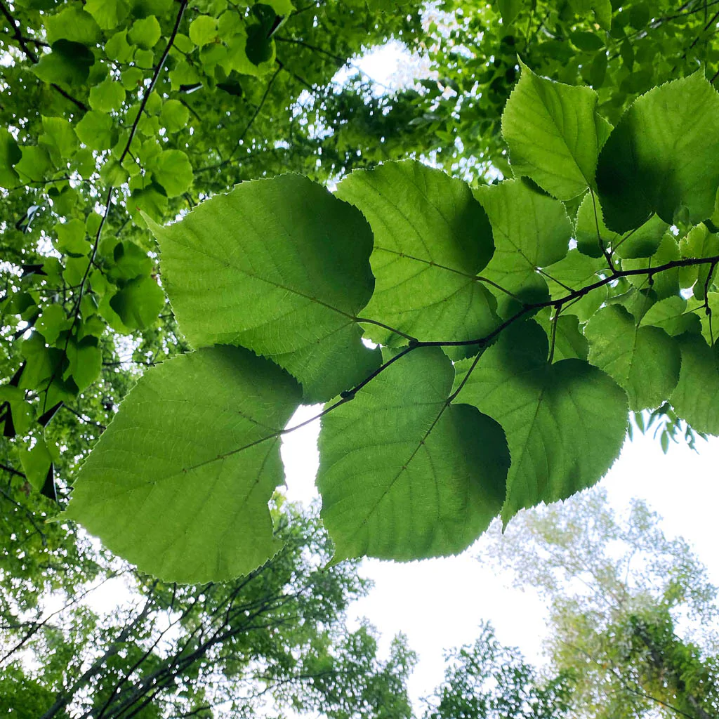

They are able to sample between 100-200 100m x 100m plots and count the number of basswood trees perfectly within each plot. Their two main variables of interest are soil acidity and slope.

They are worried that these variables are negatively correlated and might be difficult to estimate model parameters accurately.

Please design a simulation exercises that

- uses a generalized linear model framework to simulate at least 1000 data sets and estimates model parameters (per scenario)
- implements matrix multiplication to link variables to coefficients
- considers two different levels of correlation among the variables of interest (e.g., low and high)
- considers two combinations of magnitudes of effect sizes
- plots the sampling distribution of estimated coefficients
- determines the relative bias and precision of estimated coefficients
- makes a recommendation to the colleague on implications of study design (i.e., summarize your findings)

Lastly, when putting the markdown file together, define the full generalized linear model with statistical notation, e.g., as we did for logistic regression in lecture.

**Errors**: If you are getting lots of errors when fitting models for certain random datasets, don’t use apply but use a for loop to diagnose the iteration that fails so you can deternine what is happening. You can also force to skip that iteration, but make sure to record it and present these issues as part of your results/summary.